# Risk Factor Analysis

## Outcome Variable

**Outcome Variable:** ever_wasted

## Predictor Variables

**Intervention Variable:** gagebrth

**Adjustment Set:**

- arm
- sex
- W_mage
- meducyrs
- feducyrs
- hhwealth_quart
- single
- brthmon
- W_parity
- delta_W_mage
- delta_meducyrs
- delta_feducyrs
- delta_hhwealth_quart
- delta_single
- delta_brthmon
- delta_W_parity

## Stratifying Variables

The analysis was stratified on these variable(s):

- agecat
- studyid
- country

## Data Summary

| agecat | studyid | country | gagebrth | ever_wasted | n_cell | n |
| --- | --- | --- | --- | --- | --- | --- |
| 0-24 months (no birth wast) | ki1000108-CMC-V-BCS-2002 | INDIA | Full or late term | 0 | 123 | 348 |
| 0-24 months (no birth wast) | ki1000108-CMC-V-BCS-2002 | INDIA | Full or late term | 1 | 90 | 348 |
| 0-24 months (no birth wast) | ki1000108-CMC-V-BCS-2002 | INDIA | Preterm | 0 | 25 | 348 |
| 0-24 months (no birth wast) | ki1000108-CMC-V-BCS-2002 | INDIA | Preterm | 1 | 27 | 348 |
| 0-24 months (no birth wast) | ki1000108-CMC-V-BCS-2002 | INDIA | Early term | 0 | 46 | 348 |
| 0-24 months (no birth wast) | ki1000108-CMC-V-BCS-2002 | INDIA | Early term | 1 | 37 | 348 |
| 0-24 months (no birth wast) | ki1000108-IRC | INDIA | Full or late term | 0 | 121 | 389 |
| 0-24 months (no birth wast) | ki1000108-IRC | INDIA | Full or late term | 1 | 128 | 389 |
| 0-24 months (no birth wast) | ki1000108-IRC | INDIA | Preterm | 0 | 16 | 389 |
| 0-24 months (no birth wast) | ki1000108-IRC | INDIA | Preterm | 1 | 26 | 389 |
| 0-24 months (no birth wast) | ki1000108-IRC | INDIA | Early term | 0 | 44 | 389 |
| 0-24 months (no birth wast) | ki1000108-IRC | INDIA | Early term | 1 | 54 | 389 |
| 0-24 months (no birth wast) | ki1000109-EE | PAKISTAN | Full or late term | 0 | 19 | 377 |
| 0-24 months (no birth wast) | ki1000109-EE | PAKISTAN | Full or late term | 1 | 6 | 377 |
| 0-24 months (no birth wast) | ki1000109-EE | PAKISTAN | Preterm | 0 | 132 | 377 |
| 0-24 months (no birth wast) | ki1000109-EE | PAKISTAN | Preterm | 1 | 111 | 377 |
| 0-24 months (no birth wast) | ki1000109-EE | PAKISTAN | Early term | 0 | 61 | 377 |
| 0-24 months (no birth wast) | ki1000109-EE | PAKISTAN | Early term | 1 | 48 | 377 |
| 0-24 months (no birth wast) | ki1000304b-SAS-CompFeed | INDIA | Full or late term | 0 | 19 | 1487 |
| 0-24 months (no birth wast) | ki1000304b-SAS-CompFeed | INDIA | Full or late term | 1 | 9 | 1487 |
| 0-24 months (no birth wast) | ki1000304b-SAS-CompFeed | INDIA | Preterm | 0 | 862 | 1487 |
| 0-24 months (no birth wast) | ki1000304b-SAS-CompFeed | INDIA | Preterm | 1 | 496 | 1487 |
| 0-24 months (no birth wast) | ki1000304b-SAS-CompFeed | INDIA | Early term | 0 | 66 | 1487 |
| 0-24 months (no birth wast) | ki1000304b-SAS-CompFeed | INDIA | Early term | 1 | 35 | 1487 |
| 0-24 months (no birth wast) | ki1017093c-NIH-Crypto | BANGLADESH | Full or late term | 0 | 152 | 754 |
| 0-24 months (no birth wast) | ki1017093c-NIH-Crypto | BANGLADESH | Full or late term | 1 | 16 | 754 |
| 0-24 months (no birth wast) | ki1017093c-NIH-Crypto | BANGLADESH | Preterm | 0 | 214 | 754 |
| 0-24 months (no birth wast) | ki1017093c-NIH-Crypto | BANGLADESH | Preterm | 1 | 47 | 754 |
| 0-24 months (no birth wast) | ki1017093c-NIH-Crypto | BANGLADESH | Early term | 0 | 280 | 754 |
| 0-24 months (no birth wast) | ki1017093c-NIH-Crypto | BANGLADESH | Early term | 1 | 45 | 754 |

[output cut: 114 more lines]

The following strata were considered:

- agecat: 0-24 months (no birth wast), studyid: ki1000108-CMC-V-BCS-2002, country: INDIA
- agecat: 0-24 months (no birth wast), studyid: ki1000108-IRC, country: INDIA
- agecat: 0-24 months (no birth wast), studyid: ki1000109-EE, country: PAKISTAN
- agecat: 0-24 months (no birth wast), studyid: ki1000304b-SAS-CompFeed, country: INDIA
- agecat: 0-24 months (no birth wast), studyid: ki1017093c-NIH-Crypto, country: BANGLADESH
- agecat: 0-24 months (no birth wast), studyid: ki1066203-TanzaniaChild2, country: TANZANIA, UNITED REPUBLIC OF
- agecat: 0-24 months (no birth wast), studyid: ki1101329-Keneba, country: GAMBIA
- agecat: 0-24 months (no birth wast), studyid: ki1119695-PROBIT, country: BELARUS
- agecat: 0-24 months (no birth wast), studyid: ki1135781-COHORTS, country: GUATEMALA
- agecat: 0-24 months (no birth wast), studyid: ki1135781-COHORTS, country: INDIA
- agecat: 0-24 months (no birth wast), studyid: ki1135781-COHORTS, country: PHILIPPINES
- agecat: 0-24 months (no birth wast), studyid: kiGH5241-JiVitA-3, country: BANGLADESH
- agecat: 6-24 months, studyid: ki1000108-CMC-V-BCS-2002, country: INDIA
- agecat: 6-24 months, studyid: ki1000108-IRC, country: INDIA
- agecat: 6-24 months, studyid: ki1000109-EE, country: PAKISTAN
- agecat: 6-24 months, studyid: ki1000304b-SAS-CompFeed, country: INDIA
- agecat: 6-24 months, studyid: ki1017093c-NIH-Crypto, country: BANGLADESH
- agecat: 6-24 months, studyid: ki1066203-TanzaniaChild2, country: TANZANIA, UNITED REPUBLIC OF
- agecat: 6-24 months, studyid: ki1101329-Keneba, country: GAMBIA
- agecat: 6-24 months, studyid: ki1119695-PROBIT, country: BELARUS
- agecat: 6-24 months, studyid: ki1135781-COHORTS, country: GUATEMALA
- agecat: 6-24 months, studyid: ki1135781-COHORTS, country: INDIA
- agecat: 6-24 months, studyid: ki1135781-COHORTS, country: PHILIPPINES
- agecat: 6-24 months, studyid: kiGH5241-JiVitA-3, country: BANGLADESH

### Dropped Strata

Some strata were dropped due to rare outcomes:

- agecat: 6-24 months, studyid: ki1000109-EE, country: PAKISTAN

## Methods Detail

We’re interested in the causal parameters $E[Y_a]$ for all values of $a \in \mathcal{A}$. These parameters represent the mean outcome if, possibly contrary to fact, we intervened to set all units to have $A=a$. Under the randomization and positivity assumptions, these are identified by the statistical parameters $\psi_a=E_W[E_{Y|A,W}(Y|A=a,W)]$. In addition, we’re interested in the mean of $Y$, $E[Y]$ under no intervention (the observed mean). We will estimate these parameters by using SuperLearner to fit the relevant likelihood factors – $E_{Y|A,W}(Y|A=a,W)$ and $p(A=a|W)$, and then updating our likelihood fit using a joint TMLE.

For unadjusted analyses ($W=\{\}$), initial likelihoods were estimated using Lrnr_glm to estimate the simple $E(Y|A)$ and Lrnr_mean to estimate $p(A)$. For adjusted analyses, a small library containing Lrnr_glmnet, Lrnr_xgboost, and Lrnr_mean was used.

Having estimated these parameters, we will then use the delta method to estimate relative risks and attributable risks relative to a prespecified baseline level of $A$.

# Results Detail

## Results Plots

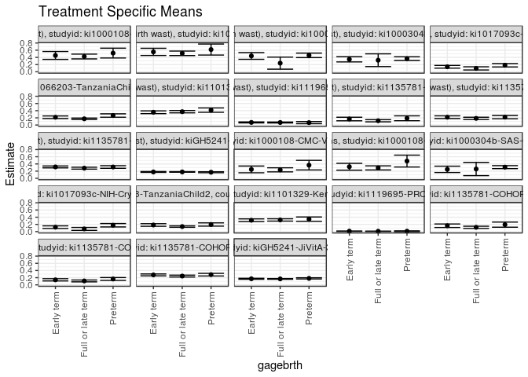

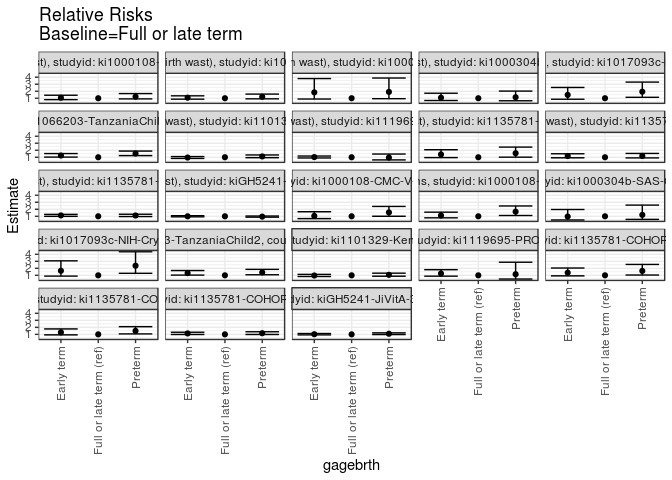

[figure not shown]

[figure not shown]

## Results Table

### Parameter: TSM

| agecat | studyid | country | intervention_level | baseline_level | estimate | ci_lower | ci_upper |
| --- | --- | --- | --- | --- | --- | --- | --- |
| 0-24 months (no birth wast) | ki1000108-CMC-V-BCS-2002 | INDIA | Full or late term | NA | 0.4243231 | 0.3576229 | 0.4910233 |
| 0-24 months (no birth wast) | ki1000108-CMC-V-BCS-2002 | INDIA | Preterm | NA | 0.5197415 | 0.3832790 | 0.6562040 |
| 0-24 months (no birth wast) | ki1000108-CMC-V-BCS-2002 | INDIA | Early term | NA | 0.4540982 | 0.3446997 | 0.5634966 |
| 0-24 months (no birth wast) | ki1000108-IRC | INDIA | Full or late term | NA | 0.5128218 | 0.4506109 | 0.5750328 |
| 0-24 months (no birth wast) | ki1000108-IRC | INDIA | Preterm | NA | 0.6180341 | 0.4648859 | 0.7711823 |
| 0-24 months (no birth wast) | ki1000108-IRC | INDIA | Early term | NA | 0.5531166 | 0.4531116 | 0.6531217 |
| 0-24 months (no birth wast) | ki1000109-EE | PAKISTAN | Full or late term | NA | 0.2400000 | 0.0723640 | 0.4076360 |
| 0-24 months (no birth wast) | ki1000109-EE | PAKISTAN | Preterm | NA | 0.4567901 | 0.3940762 | 0.5195040 |
| 0-24 months (no birth wast) | ki1000109-EE | PAKISTAN | Early term | NA | 0.4403670 | 0.3470479 | 0.5336861 |
| 0-24 months (no birth wast) | ki1000304b-SAS-CompFeed | INDIA | Full or late term | NA | 0.3214286 | 0.1438525 | 0.4990046 |
| 0-24 months (no birth wast) | ki1000304b-SAS-CompFeed | INDIA | Preterm | NA | 0.3652430 | 0.3139329 | 0.4165531 |
| 0-24 months (no birth wast) | ki1000304b-SAS-CompFeed | INDIA | Early term | NA | 0.3465347 | 0.2741080 | 0.4189613 |
| 0-24 months (no birth wast) | ki1017093c-NIH-Crypto | BANGLADESH | Full or late term | NA | 0.0939640 | 0.0499862 | 0.1379417 |
| 0-24 months (no birth wast) | ki1017093c-NIH-Crypto | BANGLADESH | Preterm | NA | 0.1813831 | 0.1342447 | 0.2285214 |
| 0-24 months (no birth wast) | ki1017093c-NIH-Crypto | BANGLADESH | Early term | NA | 0.1384234 | 0.1005337 | 0.1763132 |
| 0-24 months (no birth wast) | ki1066203-TanzaniaChild2 | TANZANIA, UNITED REPUBLIC OF | Full or late term | NA | 0.1735943 | 0.1536352 | 0.1935533 |
| 0-24 months (no birth wast) | ki1066203-TanzaniaChild2 | TANZANIA, UNITED REPUBLIC OF | Preterm | NA | 0.2649484 | 0.2181973 | 0.3116995 |
| 0-24 months (no birth wast) | ki1066203-TanzaniaChild2 | TANZANIA, UNITED REPUBLIC OF | Early term | NA | 0.2166498 | 0.1806284 | 0.2526712 |
| 0-24 months (no birth wast) | ki1101329-Keneba | GAMBIA | Full or late term | NA | 0.3712496 | 0.3386697 | 0.4038295 |
| 0-24 months (no birth wast) | ki1101329-Keneba | GAMBIA | Preterm | NA | 0.4149712 | 0.3542736 | 0.4756688 |
| 0-24 months (no birth wast) | ki1101329-Keneba | GAMBIA | Early term | NA | 0.3557807 | 0.3176249 | 0.3939364 |
| 0-24 months (no birth wast) | ki1119695-PROBIT | BELARUS | Full or late term | NA | 0.0709728 | 0.0578956 | 0.0840501 |
| 0-24 months (no birth wast) | ki1119695-PROBIT | BELARUS | Preterm | NA | 0.0677293 | 0.0379519 | 0.0975066 |
| 0-24 months (no birth wast) | ki1119695-PROBIT | BELARUS | Early term | NA | 0.0727789 | 0.0598166 | 0.0857411 |
| 0-24 months (no birth wast) | ki1135781-COHORTS | GUATEMALA | Full or late term | NA | 0.1192627 | 0.0889349 | 0.1495904 |
| 0-24 months (no birth wast) | ki1135781-COHORTS | GUATEMALA | Preterm | NA | 0.1878353 | 0.1200524 | 0.2556183 |
| 0-24 months (no birth wast) | ki1135781-COHORTS | GUATEMALA | Early term | NA | 0.1675426 | 0.1182314 | 0.2168539 |
| 0-24 months (no birth wast) | ki1135781-COHORTS | INDIA | Full or late term | NA | 0.1855149 | 0.1538078 | 0.2172221 |
| 0-24 months (no birth wast) | ki1135781-COHORTS | INDIA | Preterm | NA | 0.2195714 | 0.1739152 | 0.2652276 |
| 0-24 months (no birth wast) | ki1135781-COHORTS | INDIA | Early term | NA | 0.2181359 | 0.1806543 | 0.2556175 |
| 0-24 months (no birth wast) | ki1135781-COHORTS | PHILIPPINES | Full or late term | NA | 0.2824899 | 0.2565124 | 0.3084674 |
| 0-24 months (no birth wast) | ki1135781-COHORTS | PHILIPPINES | Preterm | NA | 0.3147926 | 0.2787037 | 0.3508815 |
| 0-24 months (no birth wast) | ki1135781-COHORTS | PHILIPPINES | Early term | NA | 0.3168500 | 0.2905705 | 0.3431296 |
| 0-24 months (no birth wast) | kiGH5241-JiVitA-3 | BANGLADESH | Full or late term | NA | 0.1775501 | 0.1691550 | 0.1859452 |
| 0-24 months (no birth wast) | kiGH5241-JiVitA-3 | BANGLADESH | Preterm | NA | 0.1690697 | 0.1563125 | 0.1818269 |
| 0-24 months (no birth wast) | kiGH5241-JiVitA-3 | BANGLADESH | Early term | NA | 0.1770962 | 0.1654765 | 0.1887159 |
| 6-24 months | ki1000108-CMC-V-BCS-2002 | INDIA | Full or late term | NA | 0.2357699 | 0.1786784 | 0.2928614 |
| 6-24 months | ki1000108-CMC-V-BCS-2002 | INDIA | Preterm | NA | 0.3660932 | 0.2328352 | 0.4993513 |
| 6-24 months | ki1000108-CMC-V-BCS-2002 | INDIA | Early term | NA | 0.2478866 | 0.1541037 | 0.3416695 |
| 6-24 months | ki1000108-IRC | INDIA | Full or late term | NA | 0.2891655 | 0.2321569 | 0.3461741 |
| 6-24 months | ki1000108-IRC | INDIA | Preterm | NA | 0.4799052 | 0.3142584 | 0.6455521 |
| 6-24 months | ki1000108-IRC | INDIA | Early term | NA | 0.3219429 | 0.2267147 | 0.4171712 |
| 6-24 months | ki1000304b-SAS-CompFeed | INDIA | Full or late term | NA | 0.2592593 | 0.0748969 | 0.4436216 |
| 6-24 months | ki1000304b-SAS-CompFeed | INDIA | Preterm | NA | 0.3113057 | 0.2697687 | 0.3528428 |
| 6-24 months | ki1000304b-SAS-CompFeed | INDIA | Early term | NA | 0.2500000 | 0.1619881 | 0.3380119 |
| 6-24 months | ki1017093c-NIH-Crypto | BANGLADESH | Full or late term | NA | 0.0746347 | 0.0338386 | 0.1154308 |
| 6-24 months | ki1017093c-NIH-Crypto | BANGLADESH | Preterm | NA | 0.1770414 | 0.1297470 | 0.2243357 |
| 6-24 months | ki1017093c-NIH-Crypto | BANGLADESH | Early term | NA | 0.1230381 | 0.0866829 | 0.1593932 |
| 6-24 months | ki1066203-TanzaniaChild2 | TANZANIA, UNITED REPUBLIC OF | Full or late term | NA | 0.1396700 | 0.1196933 | 0.1596468 |
| 6-24 months | ki1066203-TanzaniaChild2 | TANZANIA, UNITED REPUBLIC OF | Preterm | NA | 0.1971650 | 0.1518002 | 0.2425299 |
| 6-24 months | ki1066203-TanzaniaChild2 | TANZANIA, UNITED REPUBLIC OF | Early term | NA | 0.1839577 | 0.1475139 | 0.2204014 |
| 6-24 months | ki1101329-Keneba | GAMBIA | Full or late term | NA | 0.3241120 | 0.2921050 | 0.3561191 |
| 6-24 months | ki1101329-Keneba | GAMBIA | Preterm | NA | 0.3461782 | 0.2860797 | 0.4062767 |
| 6-24 months | ki1101329-Keneba | GAMBIA | Early term | NA | 0.3153495 | 0.2777075 | 0.3529915 |
| 6-24 months | ki1119695-PROBIT | BELARUS | Full or late term | NA | 0.0089633 | 0.0061435 | 0.0117831 |
| 6-24 months | ki1119695-PROBIT | BELARUS | Preterm | NA | 0.0103448 | -0.0000468 | 0.0207365 |
| 6-24 months | ki1119695-PROBIT | BELARUS | Early term | NA | 0.0112747 | 0.0075006 | 0.0150488 |
| 6-24 months | ki1135781-COHORTS | GUATEMALA | Full or late term | NA | 0.1187686 | 0.0879114 | 0.1496259 |
| 6-24 months | ki1135781-COHORTS | GUATEMALA | Preterm | NA | 0.1932504 | 0.1224734 | 0.2640274 |
| 6-24 months | ki1135781-COHORTS | GUATEMALA | Early term | NA | 0.1629424 | 0.1140757 | 0.2118091 |
| 6-24 months | ki1135781-COHORTS | INDIA | Full or late term | NA | 0.1095512 | 0.0838122 | 0.1352901 |
| 6-24 months | ki1135781-COHORTS | INDIA | Preterm | NA | 0.1636375 | 0.1232424 | 0.2040327 |
| 6-24 months | ki1135781-COHORTS | INDIA | Early term | NA | 0.1403708 | 0.1087694 | 0.1719723 |
| 6-24 months | ki1135781-COHORTS | PHILIPPINES | Full or late term | NA | 0.2450638 | 0.2193927 | 0.2707348 |
| 6-24 months | ki1135781-COHORTS | PHILIPPINES | Preterm | NA | 0.2843074 | 0.2478648 | 0.3207501 |
| 6-24 months | ki1135781-COHORTS | PHILIPPINES | Early term | NA | 0.2773089 | 0.2510921 | 0.3035258 |
| 6-24 months | kiGH5241-JiVitA-3 | BANGLADESH | Full or late term | NA | 0.1664700 | 0.1566252 | 0.1763148 |
| 6-24 months | kiGH5241-JiVitA-3 | BANGLADESH | Preterm | NA | 0.1806992 | 0.1641736 | 0.1972248 |
| 6-24 months | kiGH5241-JiVitA-3 | BANGLADESH | Early term | NA | 0.1693475 | 0.1560036 | 0.1826913 |

### Parameter: E(Y)

| agecat | studyid | country | intervention_level | baseline_level | estimate | ci_lower | ci_upper |
| --- | --- | --- | --- | --- | --- | --- | --- |
| 0-24 months (no birth wast) | ki1000108-CMC-V-BCS-2002 | INDIA | NA | NA | 0.4425287 | 0.3902692 | 0.4947882 |
| 0-24 months (no birth wast) | ki1000108-IRC | INDIA | NA | NA | 0.5347044 | 0.4850733 | 0.5843354 |
| 0-24 months (no birth wast) | ki1000109-EE | PAKISTAN | NA | NA | 0.4376658 | 0.3875213 | 0.4878102 |
| 0-24 months (no birth wast) | ki1000304b-SAS-CompFeed | INDIA | NA | NA | 0.3631473 | 0.3130392 | 0.4132554 |
| 0-24 months (no birth wast) | ki1017093c-NIH-Crypto | BANGLADESH | NA | NA | 0.1432361 | 0.1182149 | 0.1682572 |
| 0-24 months (no birth wast) | ki1066203-TanzaniaChild2 | TANZANIA, UNITED REPUBLIC OF | NA | NA | 0.1975914 | 0.1811057 | 0.2140772 |
| 0-24 months (no birth wast) | ki1101329-Keneba | GAMBIA | NA | NA | 0.3725606 | 0.3495097 | 0.3956116 |
| 0-24 months (no birth wast) | ki1119695-PROBIT | BELARUS | NA | NA | 0.0716952 | 0.0597165 | 0.0836739 |
| 0-24 months (no birth wast) | ki1135781-COHORTS | GUATEMALA | NA | NA | 0.1470952 | 0.1226726 | 0.1715178 |
| 0-24 months (no birth wast) | ki1135781-COHORTS | INDIA | NA | NA | 0.2044610 | 0.1828992 | 0.2260227 |
| 0-24 months (no birth wast) | ki1135781-COHORTS | PHILIPPINES | NA | NA | 0.3030404 | 0.2865732 | 0.3195077 |
| 0-24 months (no birth wast) | kiGH5241-JiVitA-3 | BANGLADESH | NA | NA | 0.1756674 | 0.1694118 | 0.1819231 |
| 6-24 months | ki1000108-CMC-V-BCS-2002 | INDIA | NA | NA | 0.2592593 | 0.2133485 | 0.3051700 |
| 6-24 months | ki1000108-IRC | INDIA | NA | NA | 0.3179487 | 0.2716722 | 0.3642252 |
| 6-24 months | ki1000304b-SAS-CompFeed | INDIA | NA | NA | 0.3060189 | 0.2640311 | 0.3480066 |
| 6-24 months | ki1017093c-NIH-Crypto | BANGLADESH | NA | NA | 0.1315068 | 0.1069744 | 0.1560393 |
| 6-24 months | ki1066203-TanzaniaChild2 | TANZANIA, UNITED REPUBLIC OF | NA | NA | 0.1591987 | 0.1427306 | 0.1756669 |
| 6-24 months | ki1101329-Keneba | GAMBIA | NA | NA | 0.3247706 | 0.3020649 | 0.3474764 |
| 6-24 months | ki1119695-PROBIT | BELARUS | NA | NA | 0.0100615 | 0.0072668 | 0.0128561 |
| 6-24 months | ki1135781-COHORTS | GUATEMALA | NA | NA | 0.1443433 | 0.1194882 | 0.1691984 |
| 6-24 months | ki1135781-COHORTS | INDIA | NA | NA | 0.1318764 | 0.1136647 | 0.1500881 |
| 6-24 months | ki1135781-COHORTS | PHILIPPINES | NA | NA | 0.2669537 | 0.2505274 | 0.2833801 |
| 6-24 months | kiGH5241-JiVitA-3 | BANGLADESH | NA | NA | 0.1700055 | 0.1628870 | 0.1771239 |

### Parameter: RR

| agecat | studyid | country | intervention_level | baseline_level | estimate | ci_lower | ci_upper |
| --- | --- | --- | --- | --- | --- | --- | --- |
| 0-24 months (no birth wast) | ki1000108-CMC-V-BCS-2002 | INDIA | Full or late term | Full or late term | 1.0000000 | 1.0000000 | 1.000000 |
| 0-24 months (no birth wast) | ki1000108-CMC-V-BCS-2002 | INDIA | Preterm | Full or late term | 1.2248721 | 0.9018196 | 1.663649 |
| 0-24 months (no birth wast) | ki1000108-CMC-V-BCS-2002 | INDIA | Early term | Full or late term | 1.0701707 | 0.8024421 | 1.427225 |
| 0-24 months (no birth wast) | ki1000108-IRC | INDIA | Full or late term | Full or late term | 1.0000000 | 1.0000000 | 1.000000 |
| 0-24 months (no birth wast) | ki1000108-IRC | INDIA | Preterm | Full or late term | 1.2051634 | 0.9140977 | 1.588910 |
| 0-24 months (no birth wast) | ki1000108-IRC | INDIA | Early term | Full or late term | 1.0785747 | 0.8676745 | 1.340737 |
| 0-24 months (no birth wast) | ki1000109-EE | PAKISTAN | Full or late term | Full or late term | 1.0000000 | 1.0000000 | 1.000000 |
| 0-24 months (no birth wast) | ki1000109-EE | PAKISTAN | Preterm | Full or late term | 1.9032922 | 0.9340145 | 3.878442 |
| 0-24 months (no birth wast) | ki1000109-EE | PAKISTAN | Early term | Full or late term | 1.8348624 | 0.8843059 | 3.807189 |
| 0-24 months (no birth wast) | ki1000304b-SAS-CompFeed | INDIA | Full or late term | Full or late term | 1.0000000 | 1.0000000 | 1.000000 |
| 0-24 months (no birth wast) | ki1000304b-SAS-CompFeed | INDIA | Preterm | Full or late term | 1.1363116 | 0.6396536 | 2.018599 |
| 0-24 months (no birth wast) | ki1000304b-SAS-CompFeed | INDIA | Early term | Full or late term | 1.0781078 | 0.6775643 | 1.715433 |
| 0-24 months (no birth wast) | ki1017093c-NIH-Crypto | BANGLADESH | Full or late term | Full or late term | 1.0000000 | 1.0000000 | 1.000000 |
| 0-24 months (no birth wast) | ki1017093c-NIH-Crypto | BANGLADESH | Preterm | Full or late term | 1.9303471 | 1.1300375 | 3.297448 |
| 0-24 months (no birth wast) | ki1017093c-NIH-Crypto | BANGLADESH | Early term | Full or late term | 1.4731544 | 0.8564316 | 2.533984 |
| 0-24 months (no birth wast) | ki1066203-TanzaniaChild2 | TANZANIA, UNITED REPUBLIC OF | Full or late term | Full or late term | 1.0000000 | 1.0000000 | 1.000000 |
| 0-24 months (no birth wast) | ki1066203-TanzaniaChild2 | TANZANIA, UNITED REPUBLIC OF | Preterm | Full or late term | 1.5262511 | 1.2367972 | 1.883447 |
| 0-24 months (no birth wast) | ki1066203-TanzaniaChild2 | TANZANIA, UNITED REPUBLIC OF | Early term | Full or late term | 1.2480239 | 1.0193671 | 1.527971 |
| 0-24 months (no birth wast) | ki1101329-Keneba | GAMBIA | Full or late term | Full or late term | 1.0000000 | 1.0000000 | 1.000000 |
| 0-24 months (no birth wast) | ki1101329-Keneba | GAMBIA | Preterm | Full or late term | 1.1177688 | 0.9426712 | 1.325390 |
| 0-24 months (no birth wast) | ki1101329-Keneba | GAMBIA | Early term | Full or late term | 0.9583328 | 0.8350505 | 1.099816 |
| 0-24 months (no birth wast) | ki1119695-PROBIT | BELARUS | Full or late term | Full or late term | 1.0000000 | 1.0000000 | 1.000000 |
| 0-24 months (no birth wast) | ki1119695-PROBIT | BELARUS | Preterm | Full or late term | 0.9542984 | 0.6243128 | 1.458701 |
| 0-24 months (no birth wast) | ki1119695-PROBIT | BELARUS | Early term | Full or late term | 1.0254473 | 0.8965907 | 1.172823 |
| 0-24 months (no birth wast) | ki1135781-COHORTS | GUATEMALA | Full or late term | Full or late term | 1.0000000 | 1.0000000 | 1.000000 |
| 0-24 months (no birth wast) | ki1135781-COHORTS | GUATEMALA | Preterm | Full or late term | 1.5749719 | 1.0121751 | 2.450699 |
| 0-24 months (no birth wast) | ki1135781-COHORTS | GUATEMALA | Early term | Full or late term | 1.4048207 | 0.9523719 | 2.072217 |
| 0-24 months (no birth wast) | ki1135781-COHORTS | INDIA | Full or late term | Full or late term | 1.0000000 | 1.0000000 | 1.000000 |
| 0-24 months (no birth wast) | ki1135781-COHORTS | INDIA | Preterm | Full or late term | 1.1835781 | 0.9051333 | 1.547681 |
| 0-24 months (no birth wast) | ki1135781-COHORTS | INDIA | Early term | Full or late term | 1.1758402 | 0.9240347 | 1.496264 |
| 0-24 months (no birth wast) | ki1135781-COHORTS | PHILIPPINES | Full or late term | Full or late term | 1.0000000 | 1.0000000 | 1.000000 |
| 0-24 months (no birth wast) | ki1135781-COHORTS | PHILIPPINES | Preterm | Full or late term | 1.1143501 | 0.9621676 | 1.290603 |
| 0-24 months (no birth wast) | ki1135781-COHORTS | PHILIPPINES | Early term | Full or late term | 1.1216331 | 0.9910877 | 1.269374 |
| 0-24 months (no birth wast) | kiGH5241-JiVitA-3 | BANGLADESH | Full or late term | Full or late term | 1.0000000 | 1.0000000 | 1.000000 |
| 0-24 months (no birth wast) | kiGH5241-JiVitA-3 | BANGLADESH | Preterm | Full or late term | 0.9522367 | 0.8737979 | 1.037717 |
| 0-24 months (no birth wast) | kiGH5241-JiVitA-3 | BANGLADESH | Early term | Full or late term | 0.9974436 | 0.9213756 | 1.079792 |
| 6-24 months | ki1000108-CMC-V-BCS-2002 | INDIA | Full or late term | Full or late term | 1.0000000 | 1.0000000 | 1.000000 |
| 6-24 months | ki1000108-CMC-V-BCS-2002 | INDIA | Preterm | Full or late term | 1.5527563 | 1.0026256 | 2.404738 |
| 6-24 months | ki1000108-CMC-V-BCS-2002 | INDIA | Early term | Full or late term | 1.0513918 | 0.6707229 | 1.648110 |
| 6-24 months | ki1000108-IRC | INDIA | Full or late term | Full or late term | 1.0000000 | 1.0000000 | 1.000000 |
| 6-24 months | ki1000108-IRC | INDIA | Preterm | Full or late term | 1.6596214 | 1.1154100 | 2.469355 |
| 6-24 months | ki1000108-IRC | INDIA | Early term | Full or late term | 1.1133519 | 0.7798629 | 1.589449 |
| 6-24 months | ki1000304b-SAS-CompFeed | INDIA | Full or late term | Full or late term | 1.0000000 | 1.0000000 | 1.000000 |
| 6-24 months | ki1000304b-SAS-CompFeed | INDIA | Preterm | Full or late term | 1.2007507 | 0.5554169 | 2.595892 |
| 6-24 months | ki1000304b-SAS-CompFeed | INDIA | Early term | Full or late term | 0.9642857 | 0.4717892 | 1.970895 |
| 6-24 months | ki1017093c-NIH-Crypto | BANGLADESH | Full or late term | Full or late term | 1.0000000 | 1.0000000 | 1.000000 |
| 6-24 months | ki1017093c-NIH-Crypto | BANGLADESH | Preterm | Full or late term | 2.3721055 | 1.2907635 | 4.359346 |
| 6-24 months | ki1017093c-NIH-Crypto | BANGLADESH | Early term | Full or late term | 1.6485372 | 0.8856828 | 3.068452 |
| 6-24 months | ki1066203-TanzaniaChild2 | TANZANIA, UNITED REPUBLIC OF | Full or late term | Full or late term | 1.0000000 | 1.0000000 | 1.000000 |
| 6-24 months | ki1066203-TanzaniaChild2 | TANZANIA, UNITED REPUBLIC OF | Preterm | Full or late term | 1.4116488 | 1.0765602 | 1.851037 |
| 6-24 months | ki1066203-TanzaniaChild2 | TANZANIA, UNITED REPUBLIC OF | Early term | Full or late term | 1.3170876 | 1.0315229 | 1.681707 |
| 6-24 months | ki1101329-Keneba | GAMBIA | Full or late term | Full or late term | 1.0000000 | 1.0000000 | 1.000000 |
| 6-24 months | ki1101329-Keneba | GAMBIA | Preterm | Full or late term | 1.0680818 | 0.8749881 | 1.303788 |
| 6-24 months | ki1101329-Keneba | GAMBIA | Early term | Full or late term | 0.9729645 | 0.8339631 | 1.135134 |
| 6-24 months | ki1119695-PROBIT | BELARUS | Full or late term | Full or late term | 1.0000000 | 1.0000000 | 1.000000 |
| 6-24 months | ki1119695-PROBIT | BELARUS | Preterm | Full or late term | 1.1541289 | 0.4648563 | 2.865430 |
| 6-24 months | ki1119695-PROBIT | BELARUS | Early term | Full or late term | 1.2578713 | 0.8760389 | 1.806130 |
| 6-24 months | ki1135781-COHORTS | GUATEMALA | Full or late term | Full or late term | 1.0000000 | 1.0000000 | 1.000000 |
| 6-24 months | ki1135781-COHORTS | GUATEMALA | Preterm | Full or late term | 1.6271165 | 1.0379766 | 2.550643 |
| 6-24 months | ki1135781-COHORTS | GUATEMALA | Early term | Full or late term | 1.3719311 | 0.9229714 | 2.039278 |
| 6-24 months | ki1135781-COHORTS | INDIA | Full or late term | Full or late term | 1.0000000 | 1.0000000 | 1.000000 |
| 6-24 months | ki1135781-COHORTS | INDIA | Preterm | Full or late term | 1.4937084 | 1.0640912 | 2.096780 |
| 6-24 months | ki1135781-COHORTS | INDIA | Early term | Full or late term | 1.2813266 | 0.9266584 | 1.771740 |
| 6-24 months | ki1135781-COHORTS | PHILIPPINES | Full or late term | Full or late term | 1.0000000 | 1.0000000 | 1.000000 |
| 6-24 months | ki1135781-COHORTS | PHILIPPINES | Preterm | Full or late term | 1.1601366 | 0.9833681 | 1.368681 |
| 6-24 months | ki1135781-COHORTS | PHILIPPINES | Early term | Full or late term | 1.1315788 | 0.9828082 | 1.302869 |
| 6-24 months | kiGH5241-JiVitA-3 | BANGLADESH | Full or late term | Full or late term | 1.0000000 | 1.0000000 | 1.000000 |
| 6-24 months | kiGH5241-JiVitA-3 | BANGLADESH | Preterm | Full or late term | 1.0854762 | 0.9737603 | 1.210009 |
| 6-24 months | kiGH5241-JiVitA-3 | BANGLADESH | Early term | Full or late term | 1.0172854 | 0.9210538 | 1.123571 |

### Parameter: PAR

| agecat | studyid | country | intervention_level | baseline_level | estimate | ci_lower | ci_upper |
| --- | --- | --- | --- | --- | --- | --- | --- |
| 0-24 months (no birth wast) | ki1000108-CMC-V-BCS-2002 | INDIA | Full or late term | NA | 0.0182056 | -0.0237922 | 0.0602035 |
| 0-24 months (no birth wast) | ki1000108-IRC | INDIA | Full or late term | NA | 0.0218825 | -0.0155439 | 0.0593090 |
| 0-24 months (no birth wast) | ki1000109-EE | PAKISTAN | Full or late term | NA | 0.1976658 | 0.0336863 | 0.3616452 |
| 0-24 months (no birth wast) | ki1000304b-SAS-CompFeed | INDIA | Full or late term | NA | 0.0417187 | -0.1370436 | 0.2204810 |
| 0-24 months (no birth wast) | ki1017093c-NIH-Crypto | BANGLADESH | Full or late term | NA | 0.0492721 | 0.0081246 | 0.0904196 |
| 0-24 months (no birth wast) | ki1066203-TanzaniaChild2 | TANZANIA, UNITED REPUBLIC OF | Full or late term | NA | 0.0239972 | 0.0106312 | 0.0373632 |
| 0-24 months (no birth wast) | ki1101329-Keneba | GAMBIA | Full or late term | NA | 0.0013110 | -0.0217884 | 0.0244105 |
| 0-24 months (no birth wast) | ki1119695-PROBIT | BELARUS | Full or late term | NA | 0.0007224 | -0.0037305 | 0.0051753 |
| 0-24 months (no birth wast) | ki1135781-COHORTS | GUATEMALA | Full or late term | NA | 0.0278325 | 0.0054057 | 0.0502594 |
| 0-24 months (no birth wast) | ki1135781-COHORTS | INDIA | Full or late term | NA | 0.0189460 | -0.0053830 | 0.0432751 |
| 0-24 months (no birth wast) | ki1135781-COHORTS | PHILIPPINES | Full or late term | NA | 0.0205505 | -0.0000161 | 0.0411172 |
| 0-24 months (no birth wast) | kiGH5241-JiVitA-3 | BANGLADESH | Full or late term | NA | -0.0018827 | -0.0075021 | 0.0037368 |
| 6-24 months | ki1000108-CMC-V-BCS-2002 | INDIA | Full or late term | NA | 0.0234893 | -0.0138231 | 0.0608018 |
| 6-24 months | ki1000108-IRC | INDIA | Full or late term | NA | 0.0287832 | -0.0071112 | 0.0646777 |
| 6-24 months | ki1000304b-SAS-CompFeed | INDIA | Full or late term | NA | 0.0467596 | -0.1497850 | 0.2433042 |
| 6-24 months | ki1017093c-NIH-Crypto | BANGLADESH | Full or late term | NA | 0.0568722 | 0.0176462 | 0.0960981 |
| 6-24 months | ki1066203-TanzaniaChild2 | TANZANIA, UNITED REPUBLIC OF | Full or late term | NA | 0.0195287 | 0.0059491 | 0.0331083 |
| 6-24 months | ki1101329-Keneba | GAMBIA | Full or late term | NA | 0.0006586 | -0.0219191 | 0.0232363 |
| 6-24 months | ki1119695-PROBIT | BELARUS | Full or late term | NA | 0.0010981 | -0.0006579 | 0.0028542 |
| 6-24 months | ki1135781-COHORTS | GUATEMALA | Full or late term | NA | 0.0255747 | 0.0028903 | 0.0482590 |
| 6-24 months | ki1135781-COHORTS | INDIA | Full or late term | NA | 0.0223252 | 0.0020224 | 0.0426280 |
| 6-24 months | ki1135781-COHORTS | PHILIPPINES | Full or late term | NA | 0.0218900 | 0.0014894 | 0.0422905 |
| 6-24 months | kiGH5241-JiVitA-3 | BANGLADESH | Full or late term | NA | 0.0035355 | -0.0033599 | 0.0104308 |

### Parameter: PAF

| agecat | studyid | country | intervention_level | baseline_level | estimate | ci_lower | ci_upper |
| --- | --- | --- | --- | --- | --- | --- | --- |
| 0-24 months (no birth wast) | ki1000108-CMC-V-BCS-2002 | INDIA | Full or late term | NA | 0.0411400 | -0.0587008 | 0.1315653 |
| 0-24 months (no birth wast) | ki1000108-IRC | INDIA | Full or late term | NA | 0.0409246 | -0.0318051 | 0.1085277 |
| 0-24 months (no birth wast) | ki1000109-EE | PAKISTAN | Full or late term | NA | 0.4516364 | -0.0848875 | 0.7228259 |
| 0-24 months (no birth wast) | ki1000304b-SAS-CompFeed | INDIA | Full or late term | NA | 0.1148810 | -0.5395125 | 0.4911144 |
| 0-24 months (no birth wast) | ki1017093c-NIH-Crypto | BANGLADESH | Full or late term | NA | 0.3439923 | -0.0087437 | 0.5733840 |
| 0-24 months (no birth wast) | ki1066203-TanzaniaChild2 | TANZANIA, UNITED REPUBLIC OF | Full or late term | NA | 0.1214485 | 0.0516062 | 0.1861474 |
| 0-24 months (no birth wast) | ki1101329-Keneba | GAMBIA | Full or late term | NA | 0.0035189 | -0.0604521 | 0.0636309 |
| 0-24 months (no birth wast) | ki1119695-PROBIT | BELARUS | Full or late term | NA | 0.0100758 | -0.0541764 | 0.0704119 |
| 0-24 months (no birth wast) | ki1135781-COHORTS | GUATEMALA | Full or late term | NA | 0.1892143 | 0.0237957 | 0.3266026 |
| 0-24 months (no birth wast) | ki1135781-COHORTS | INDIA | Full or late term | NA | 0.0926634 | -0.0343939 | 0.2041138 |
| 0-24 months (no birth wast) | ki1135781-COHORTS | PHILIPPINES | Full or late term | NA | 0.0678145 | -0.0025794 | 0.1332658 |
| 0-24 months (no birth wast) | kiGH5241-JiVitA-3 | BANGLADESH | Full or late term | NA | -0.0107172 | -0.0432217 | 0.0207745 |
| 6-24 months | ki1000108-CMC-V-BCS-2002 | INDIA | Full or late term | NA | 0.0906018 | -0.0650587 | 0.2235121 |
| 6-24 months | ki1000108-IRC | INDIA | Full or late term | NA | 0.0905279 | -0.0297345 | 0.1967450 |
| 6-24 months | ki1000304b-SAS-CompFeed | INDIA | Full or late term | NA | 0.1527997 | -0.7914569 | 0.5993494 |
| 6-24 months | ki1017093c-NIH-Crypto | BANGLADESH | Full or late term | NA | 0.4324654 | 0.0554799 | 0.6589850 |
| 6-24 months | ki1066203-TanzaniaChild2 | TANZANIA, UNITED REPUBLIC OF | Full or late term | NA | 0.1226687 | 0.0338149 | 0.2033511 |
| 6-24 months | ki1101329-Keneba | GAMBIA | Full or late term | NA | 0.0020279 | -0.0699697 | 0.0691809 |
| 6-24 months | ki1119695-PROBIT | BELARUS | Full or late term | NA | 0.1091425 | -0.0756863 | 0.2622133 |
| 6-24 months | ki1135781-COHORTS | GUATEMALA | Full or late term | NA | 0.1771794 | 0.0063409 | 0.3186459 |
| 6-24 months | ki1135781-COHORTS | INDIA | Full or late term | NA | 0.1692890 | 0.0011083 | 0.3091536 |
| 6-24 months | ki1135781-COHORTS | PHILIPPINES | Full or late term | NA | 0.0819991 | 0.0023482 | 0.1552908 |
| 6-24 months | kiGH5241-JiVitA-3 | BANGLADESH | Full or late term | NA | 0.0207962 | -0.0206127 | 0.0605250 |